# Factorial Designs: Higher-Order and Fractional Designs

Extending Factorials Beyond 2×2 — Week 7

Dr. Samuel B Fernandes

2026-01-01

## Learning Objectives

By the end of this lecture, you should be able to:

- Extend the 2×2 factorial workflow to higher-order designs (3×3, 2×2×2)
- Analyze and interpret interactions with more than two levels or three factors
- Recognize three-way interactions and decide when they matter practically
- Understand the concept and motivation for fractional factorial designs ($2^{k-p}$)
- Make informed design decisions about factorial complexity, sample size, and power tradeoffs

# 3×3 Factorial Designs

## Expanding to 3 Levels

**3×3 Factorial:**

- **Two factors**, each with **3 levels**
- **9 treatment combinations** (3×3)
- More detailed dose-response information

**Example:** Nitrogen (0, 50, 100 kg/ha) × Irrigation (Low, Medium, High)

**Treatment combinations table:**

| Irrigation | N = 0 | N = 50 | N = 100 |
| --- | --- | --- | --- |
| **Low** | L0 | L50 | L100 |
| **Medium** | M0 | M50 | M100 |
| **High** | H0 | H50 | H100 |

**When to prefer 3 levels:** Use 3 levels when you need to detect a **dose-response curve** or find an optimal rate (fertilizer, herbicide). Two levels only test high vs. low; three levels reveal whether the response is linear or quadratic.

## ANOVA for 3×3 Factorial

**ANOVA structure:**

$$\text{SS}_{\text{Total}} = \text{SS}_A + \text{SS}_B + \text{SS}_{A \times B} + \text{SS}_{\text{Error}}$$

**Degrees of freedom:**

- Factor A (3 levels): $a - 1 = 2$ df
- Factor B (3 levels): $b - 1 = 2$ df
- Interaction A×B: $(a-1)(b-1) = 4$ df
- Error: $ab(r-1) = 9(r-1)$ df

**ANOVA table for 3×3 with 8 reps:**

| Source | df | MS | F | p |
| --- | --- | --- | --- | --- |
| **Nitrogen** | 2 | $MS_N$ | $F_N$ | $p_N$ |
| **Irrigation** | 2 | $MS_I$ | $F_I$ | $p_I$ |
| **N × I** | **4** | $MS_{N \times I}$ | $F_{N \times I}$ | $p_{N \times I}$ |
| **Error** | 63 | $MS_E$ | — | — |
| **Total** | 71 | — | — | — |

## Example: 3×3 Nitrogen × Irrigation

```r
library(dplyr)
library(ggplot2)
library(car)
library(emmeans)

# Simulate 3×3 factorial data
set.seed(2026)
data_3x3 <- expand.grid(
  Nitrogen   = factor(c("0", "50", "100"), levels = c("0", "50", "100")),
  Irrigation = factor(c("Low", "Medium", "High"), levels = c("Low", "Medium", "High")),
  Rep        = 1:8
) |>
  mutate(
    mu = case_when(
      Nitrogen == "0"   & Irrigation == "Low"    ~ 2800,
      Nitrogen == "50"  & Irrigation == "Low"    ~ 2900,
      Nitrogen == "100" & Irrigation == "Low"    ~ 3000,
      Nitrogen == "0"   & Irrigation == "Medium" ~ 3200,
      Nitrogen == "50"  & Irrigation == "Medium" ~ 3500,
      Nitrogen == "100" & Irrigation == "Medium" ~ 3800,
      Nitrogen == "0"   & Irrigation == "High"   ~ 3500,
      Nitrogen == "50"  & Irrigation == "High"   ~ 4200,
      Nitrogen == "100" & Irrigation == "High"   ~ 4800
    ),
    Yield = mu + rnorm(n(), mean = 0, sd = 150)
  )

# Treatment mean table
data_3x3 |>
  group_by(Nitrogen, Irrigation) |>
  summarise(Mean_Yield = round(mean(Yield), 0), .groups = "drop") |>
  tidyr::pivot_wider(names_from = Irrigation, values_from = Mean_Yield)
```

```
#> # A tibble: 3 × 4
#>   Nitrogen   Low Medium  High
#>   <fct>    <dbl>  <dbl> <dbl>
#> 1 0         2807   3129  3492
#> 2 50        2857   3471  4233
#> 3 100       2990   3683  4850
```

## Visualize 3×3 Interaction

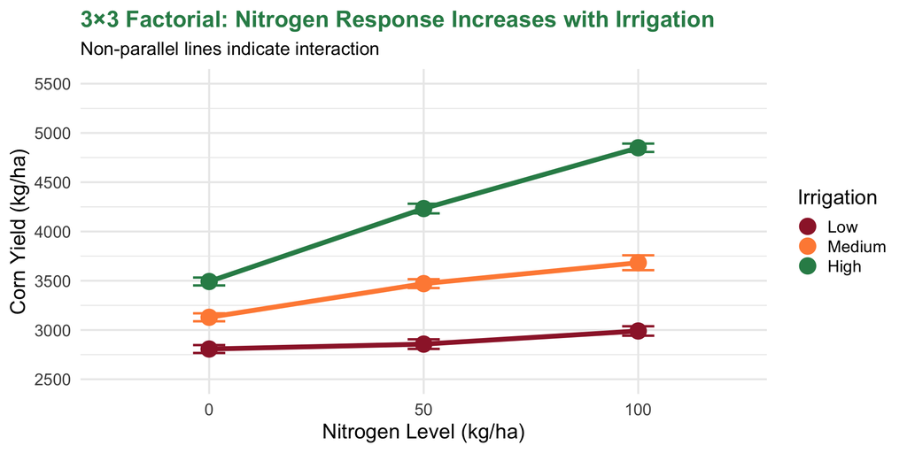

Figure 1: Interaction plot: Nitrogen × Irrigation (3×3 factorial)

```r
summary_3x3 <- data_3x3 |>
  group_by(Nitrogen, Irrigation) |>
  summarise(mean_yield = mean(Yield), se_yield = sd(Yield) / sqrt(n()), .groups = "drop")

ggplot(summary_3x3, aes(x = Nitrogen, y = mean_yield, color = Irrigation, group = Irrigation)) +
  geom_line(linewidth = 2) +
  geom_point(size = 6) +
  geom_errorbar(aes(ymin = mean_yield - se_yield, ymax = mean_yield + se_yield),
                width = 0.15, linewidth = 1) +
  labs(title = "3×3 Factorial: Nitrogen Response Increases with Irrigation",
       subtitle = "Non-parallel lines indicate interaction",
       x = "Nitrogen Level (kg/ha)", y = "Corn Yield (kg/ha)", color = "Irrigation") +
  scale_color_manual(values = c("Low" = "#9D2235", "Medium" = "#FF8C42", "High" = "#2E8B57")) +
  scale_y_continuous(limits = c(2500, 5500), breaks = seq(2500, 5500, 500)) +
  theme_minimal(base_size = 18) +
  theme(plot.title = element_text(color = "#2E8B57", face = "bold", size = 20),
        plot.subtitle = element_text(size = 16), legend.position = "right")
```

**Observation:** Lines are **not parallel** — slopes steepen from Low → Medium → High irrigation. The N × Irrigation interaction is strong: nitrogen investment pays off most under high water availability.

## ANOVA: 3×3 Factorial

```r
# Sum-to-zero contrasts required for correct Type III SS
options(contrasts = c("contr.sum", "contr.poly"))
model_3x3 <- lm(Yield ~ Nitrogen * Irrigation, data = data_3x3)
Anova(model_3x3, type = "III")
```

```
#> Anova Table (Type III tests)
#>
#> Response: Yield
#>                        Sum Sq Df   F value    Pr(>F)
#> (Intercept)         882639207  1 46405.764 < 2.2e-16 ***
#> Nitrogen              5860899  2   154.072 < 2.2e-16 ***
#> Irrigation           20691962  2   543.952 < 2.2e-16 ***
#> Nitrogen:Irrigation   2922096  4    38.408 2.965e-16 ***
#> Residuals             1198262 63
#> ---
#> Signif. codes:  0 '***' 0.001 '**' 0.01 '*' 0.05 '.' 0.1 ' ' 1
```

```r
# Restore default contrasts
options(contrasts = c("contr.treatment", "contr.poly"))
```

**ANOVA results:** The N × Irrigation interaction is significant (p < 0.001) → do **not** interpret main effects in isolation. Conduct **simple effects** analysis.

## Simple Effects: 3×3 Analysis

```r
# Simple effects: nitrogen comparisons within each irrigation level
emm_3x3 <- emmeans(model_3x3, ~ Nitrogen | Irrigation)
pairs(emm_3x3, adjust = "tukey")
```

```
#> Irrigation = Low:
#>  contrast                 estimate SE df t.ratio p.value
#>  Nitrogen0 - Nitrogen50      -49.9 69 63  -0.723  0.7509
#>  Nitrogen0 - Nitrogen100    -183.0 69 63  -2.654  0.0268
#>  Nitrogen50 - Nitrogen100   -133.2 69 63  -1.931  0.1383
#>
#> Irrigation = Medium:
#>  contrast                 estimate SE df t.ratio p.value
#>  Nitrogen0 - Nitrogen50     -341.7 69 63  -4.955  <.0001
#>  Nitrogen0 - Nitrogen100    -553.9 69 63  -8.032  <.0001
#>  Nitrogen50 - Nitrogen100   -212.2 69 63  -3.077  0.0086
#>
#> Irrigation = High:
#>  contrast                 estimate SE df t.ratio p.value
#>  Nitrogen0 - Nitrogen50     -740.5 69 63 -10.739  <.0001
#>  Nitrogen0 - Nitrogen100   -1357.4 69 63 -19.684  <.0001
#>  Nitrogen50 - Nitrogen100   -616.9 69 63  -8.946  <.0001
#>
#> P value adjustment: tukey method for comparing a family of 3 estimates
```

**Summary of nitrogen effect by irrigation level:**

| Irrigation | N effect (0 → 100 kg/ha) | Practical recommendation |
| --- | --- | --- |
| Low | ~+200 kg/ha (modest) | Marginal ROI |
| Medium | ~+600 kg/ha (moderate) | Worthwhile |
| High | ~+1300 kg/ha (large) | Strongly recommended |

**Conclusion:** Do not invest in high N rates under low irrigation — water availability limits the crop’s ability to respond to nitrogen.

# 2×2×2 Factorial Designs

## Adding a Third Factor

**2×2×2 Factorial:**

- **Three factors**, each with **2 levels**
- $2^3 =$ **8 treatment combinations**
- Tests **7** effects: 3 main effects + 3 two-way interactions + 1 three-way interaction

**Example:** Herbicide timing (PRE, POST) × Adjuvant (None, NIS) × Crop Residue (Low, High)

**Biological rationale:**

- PRE herbicides must reach the soil — residue can intercept them
- NIS enhances foliar uptake — relevant mainly for POST applications
- H×R interaction is biologically expected

**Treatment combinations:**

| Herbicide | Adjuvant | Residue |
| --- | --- | --- |
| PRE | None | Low |
| PRE | None | High |
| PRE | NIS | Low |
| PRE | NIS | High |
| POST | None | Low |
| POST | None | High |
| POST | NIS | Low |
| POST | NIS | High |

## ANOVA for 2×2×2 Factorial

**7 sources of variation:**

1. Main effect: Herbicide timing (H) — 1 df
2. Main effect: Adjuvant (A) — 1 df
3. Main effect: Residue (R) — 1 df
4. Two-way: H×A — 1 df
5. Two-way: H×R — 1 df
6. Two-way: A×R — 1 df
7. **Three-way: H×A×R** — 1 df
8. Error — 40 df *(8 combos × 6 reps − 8)*

**ANOVA table (2×2×2, 6 reps, N = 48):**

| Source | df | F | p |
| --- | --- | --- | --- |
| H | 1 | $F_H$ | $p_H$ |
| A | 1 | $F_A$ | $p_A$ |
| R | 1 | $F_R$ | $p_R$ |
| H×A | 1 | $F_{HA}$ | $p_{HA}$ |
| H×R | 1 | $F_{HR}$ | $p_{HR}$ |
| A×R | 1 | $F_{AR}$ | $p_{AR}$ |
| **H×A×R** | **1** | $F_{HAR}$ | $p_{HAR}$ |
| Error | 40 | — | — |

**Interpretation rule:** Always test the highest-order interaction first. If H×A×R is significant, the two-way interactions cannot be interpreted independently.

## Three-Way Interaction: What Does It Mean?

**Three-way interaction (H×A×R):**

The **Herbicide × Adjuvant** two-way interaction **changes depending on** the level of Crop Residue.

**Under Low Residue:**

- PRE: ~78% control (adjuvant irrelevant — soil-applied)
- POST: ~72% without NIS → ~90% with NIS
- H×A interaction is moderate

**Under High Residue:**

- PRE: drops to ~55% (residue intercepts herbicide)
- POST: ~70% without NIS → ~92% with NIS
- H×A interaction is *larger* (PRE is now strongly penalized)

**Good news:** Three-way interactions are **rare** in practice. When they occur, use **faceted interaction plots** — one panel per level of the third factor — to visualize and interpret.

## Example: 2×2×2 Herbicide Factorial

```r
# Simulate 2×2×2 herbicide factorial — response: % weed control
set.seed(2026)
data_2x2x2 <- expand.grid(
  Herbicide = factor(c("PRE", "POST"), levels = c("PRE", "POST")),
  Adjuvant  = factor(c("None", "NIS"), levels = c("None", "NIS")),
  Residue   = factor(c("Low", "High"), levels = c("Low", "High")),
  Rep       = 1:6
) |>
  mutate(
    mu = case_when(
      Herbicide == "PRE"  & Adjuvant == "None" & Residue == "Low"  ~ 78,
      Herbicide == "PRE"  & Adjuvant == "NIS"  & Residue == "Low"  ~ 80,
      Herbicide == "PRE"  & Adjuvant == "None" & Residue == "High" ~ 55,
      Herbicide == "PRE"  & Adjuvant == "NIS"  & Residue == "High" ~ 58,
      Herbicide == "POST" & Adjuvant == "None" & Residue == "Low"  ~ 72,
      Herbicide == "POST" & Adjuvant == "NIS"  & Residue == "Low"  ~ 90,
      Herbicide == "POST" & Adjuvant == "None" & Residue == "High" ~ 70,
      Herbicide == "POST" & Adjuvant == "NIS"  & Residue == "High" ~ 92
    ),
    Weed_Control = mu + rnorm(n(), mean = 0, sd = 5)
  )

data_2x2x2 |>
  group_by(Herbicide, Adjuvant, Residue) |>
  summarise(Mean_Control = round(mean(Weed_Control), 1), .groups = "drop")
```

```
#> # A tibble: 8 × 4
#>   Herbicide Adjuvant Residue Mean_Control
#>   <fct>     <fct>    <fct>          <dbl>
#> 1 PRE       None     Low             77.9
#> 2 PRE       None     High            54.3
#> 3 PRE       NIS      Low             79.7
#> 4 PRE       NIS      High            54.7
#> 5 POST      None     Low             73.4
#> 6 POST      None     High            69.5
#> 7 POST      NIS      Low             91.2
#> 8 POST      NIS      High            92.6
```

## Visualize 2×2×2: Faceted Interaction Plot

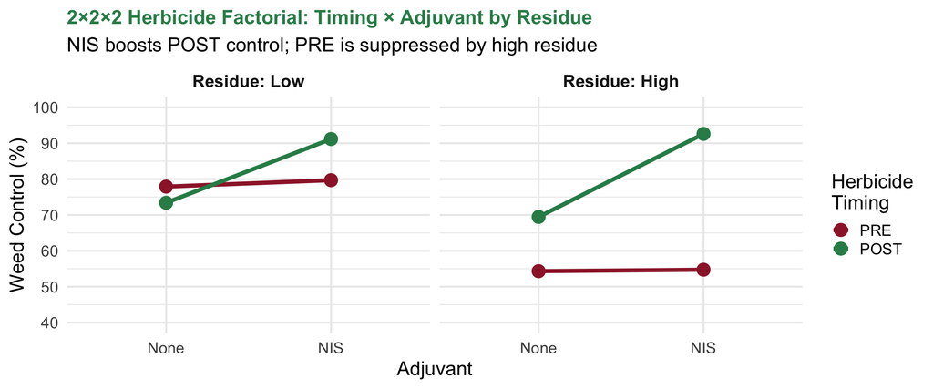

Figure 2: Herbicide × Adjuvant interaction by Residue level

```r
data_2x2x2 |>
  group_by(Herbicide, Adjuvant, Residue) |>
  summarise(mean_control = mean(Weed_Control), .groups = "drop") |>
  ggplot(aes(x = Adjuvant, y = mean_control, color = Herbicide, group = Herbicide)) +
  geom_line(linewidth = 1.8) + geom_point(size = 5) +
  facet_wrap(~Residue, labeller = label_both) +
  labs(title = "2×2×2 Herbicide Factorial: Timing × Adjuvant by Residue",
       subtitle = "NIS boosts POST control; PRE is suppressed by high residue",
       x = "Adjuvant", y = "Weed Control (%)", color = "Herbicide\nTiming") +
  scale_color_manual(values = c("PRE" = "#9D2235", "POST" = "#2E8B57")) +
  scale_y_continuous(limits = c(40, 100), breaks = seq(40, 100, 10)) +
  theme_minimal(base_size = 18) +
  theme(plot.title = element_text(color = "#2E8B57", face = "bold", size = 18),
        strip.text = element_text(size = 16, face = "bold"), legend.position = "right")
```

**Key message:** PRE drops to ~55% under high residue (soil interception). POST + NIS maintains ~92% regardless of residue. The **H×R interaction** drives the recommendation: use POST + NIS in no-till (high-residue) systems.

## ANOVA: 2×2×2 Herbicide Factorial

```r
# Sum-to-zero contrasts required for correct Type III SS
options(contrasts = c("contr.sum", "contr.poly"))
model_2x2x2 <- lm(Weed_Control ~ Herbicide * Adjuvant * Residue, data = data_2x2x2)
Anova(model_2x2x2, type = "III")
```

```
#> Anova Table (Type III tests)
#>
#> Response: Weed_Control
#>                            Sum Sq Df    F value    Pr(>F)
#> (Intercept)                264004  1 10005.8416 < 2.2e-16 ***
#> Herbicide                    2698  1   102.2382 1.402e-12 ***
#> Adjuvant                     1395  1    52.8717 7.880e-09 ***
#> Residue                      1954  1    74.0735 1.214e-10 ***
#> Herbicide:Adjuvant           1124  1    42.6108 8.574e-08 ***
#> Herbicide:Residue            1589  1    60.2305 1.672e-09 ***
#> Adjuvant:Residue               12  1     0.4575    0.5027
#> Herbicide:Adjuvant:Residue     34  1     1.3003    0.2609
#> Residuals                    1055 40
#> ---
#> Signif. codes:  0 '***' 0.001 '**' 0.01 '*' 0.05 '.' 0.1 ' ' 1
```

```r
# Restore default contrasts
options(contrasts = c("contr.treatment", "contr.poly"))
```

**Interpretation workflow:**

1. Check **H×A×R** first — if p ≥ 0.05, no three-way interaction → proceed to two-way
2. Check **H×R** and **H×A** — biologically expected to be significant
3. Agronomic threshold: identify combinations achieving **≥ 85% weed control**

# Fractional Factorial Designs

## Motivation: Too Many Factors!

**Problem:** Treatment combinations grow **exponentially** with each added factor.

| Factors (k) | Full factorial ($2^k$) | × 4 reps | Total plots |
| --- | --- | --- | --- |
| 2 | 4 |  | 16 |
| 3 | 8 |  | 32 |
| 4 | 16 |  | 64 |
| 5 | 32 |  | 128 |
| 6 | 64 |  | **256** |
| 7 | 128 |  | **512** |

**Practical constraint:** Most field experiments in weed science and agronomy accommodate **50–150 plots**. Full factorials with 5+ factors quickly exceed this capacity.

**Solution:** Test a strategically chosen **fraction** of the combinations.

## Fractional Factorials: The Concept

**Fractional factorial ($2^{k-p}$):**

- **k** factors, test only $2^{k-p}$ combinations
- **p** = number of times to halve the design
- $2^{5-1}$ = 5 factors, only $2^4 = 16$ runs (half of 32)
- $2^{6-2}$ = 6 factors, only $2^4 = 16$ runs (quarter of 64)

**Trade-off:**

- **Gain:** Feasible plot count
- **Cost:** Some effects are **aliased** (confounded with higher-order interactions)

**Strategy:** Screen many factors → identify the 2–3 that matter → follow up with full factorial on those.

**Common designs:**

| Design | Factors | Runs | Fraction |
| --- | --- | --- | --- |
| $2^{4-1}$ | 4 | 8 | 1/2 |
| $2^{5-1}$ | 5 | 16 | 1/2 |
| $2^{5-2}$ | 5 | 8 | 1/4 |
| $2^{6-2}$ | 6 | 16 | 1/4 |
| $2^{7-3}$ | 7 | 16 | 1/8 |

**Aliasing principle:** Main effects are not confounded with each other — only with high-order interactions, which are usually negligible in agricultural systems.

## Example: Screening Experiment

**Scenario:** Optimize an integrated weed management (IWM) program — 6 factors to screen:

| Factor | Levels |
| --- | --- |
| Herbicide timing | PRE, POST |
| Herbicide rate | 1×, 0.5× labeled rate |
| Cover crop | None, Cereal rye |
| Row spacing | 15”, 30” |
| Cultivation | None, Inter-row |
| Adjuvant | None, NIS |

**Full factorial:** $2^6 = 64$ combinations × 4 reps = **256 plots** (infeasible)

**Fractional factorial ($2^{6-2}$):** 16 combinations × 4 reps = **64 plots** ✓

**Two-phase research strategy:**

1. **Phase 1 — Screen:** Run $2^{6-2}$ to identify which factors have large main effects on weed control
2. **Phase 2 — Optimize:** Run full $2^3$ factorial on the 3 most important factors

## Fractional Factorial: R Package

**`FrF2` package** generates fractional factorial designs with correct aliasing structure:

```r
library(FrF2)

# Generate 2^(6-2): 16 runs, 6 IWM factors, randomized
design_frac <- FrF2(nruns = 16, nfactors = 6, randomize = TRUE,
                    factor.names = list(Timing = c("PRE", "POST"),
                                        Rate   = c("Half", "Full"),
                                        Cover  = c("None", "Rye"),
                                        Rows   = c("15in", "30in"),
                                        Cult   = c("None", "Inter"),
                                        Adj    = c("None", "NIS")))
summary(design_frac)
```

Fractional factorial **analysis** will not be discussed here check TextBook. The key takeaway: these designs exist and are powerful tools for multi-factor screening in applied weed science research.

# Design Decision Framework

## Choosing Factorial Structure

**How many factors?**

- **2–3 factors:** Full factorial usually feasible
- **4–5 factors:** Full factorial if resources allow; otherwise fractional
- **6+ factors:** Fractional factorial for initial screening

**How many levels per factor?**

- **2 levels:** Compare two conditions (yes/no, low/high)
- **3 levels:** Detect dose-response, find optimum
- **4+ levels:** Detailed curve (many plots)

**Are interactions biologically plausible?**

Ask before designing:

- “Does Factor A change *how* Factor B works mechanistically?”
- If yes → full factorial (need to estimate interactions)
- If no → separate experiment may be more efficient

**Examples where interactions are expected:**

- Herbicide rate × adjuvant (foliar uptake)
- N fertilizer × irrigation (nutrient uptake needs water)
- Cover crop × herbicide timing (additive or substitutive?)

## Sample Size Considerations

**Total plots = Combinations × Reps:**

| Design | Combos | Reps | Total |
| --- | --- | --- | --- |
| 2×2 | 4 | 8 | 32 |
| 3×3 | 9 | 8 | 72 |
| 2×2×2 | 8 | 6 | 48 |
| 3×2×2 | 12 | 6 | 72 |
| 3×3×3 | 27 | 6 | 162 |

**Power analysis with `pwr`:**

```r
library(pwr)

# 2×2 factorial: 4 groups, 8 reps per group
# Effect size f = 0.35 (moderate)
pwr.anova.test(k         = 4,
               n         = 8,
               f         = 0.35,
               sig.level = 0.05)
```

**Always run power analysis during design**, not after data collection. Use pilot data or published literature to estimate the expected effect size.

## Design Decision Checklist

**Before finalizing your factorial design, answer:**

1. ✓ **How many factors?** (2–3 ideal; ≥ 4 consider fractional)
2. ✓ **How many levels per factor?** (2 for presence/absence; 3 for dose-response)
3. ✓ **Are interactions biologically plausible?** (Justify each two-way)
4. ✓ **Total plots feasible?** (Combinations × Reps ≤ capacity)
5. ✓ **Power adequate?** (Run `pwr.anova.test()` — target ≥ 80%)
6. ✓ **CRD or RCBD?** (Block if spatial/temporal variation is expected)
7. ✓ **Can I fully randomize?** (If not → split-plot may be required)
8. ✓ **Planned analysis?** (If interaction expected: `emmeans(~ B | A)` for simple effects)

# Your Turn: Choose a Design

## Activity (3 minutes)

**Scenario:**

You want to study factors affecting Palmer amaranth control in soybean:

- **Herbicide program** (PRE-only, POST-only, PRE+POST) — 3 levels
- **Row spacing** (15-inch, 30-inch) — 2 levels
- **Cover crop** (None, Cereal rye) — 2 levels

You have space for **72 plots**.

**Questions:**

1. What factorial structure is this? (e.g., 3×2×2)
2. How many treatment combinations?
3. How many reps with 72 plots?
4. Full factorial or simplify? Why?
5. What interactions are most biologically relevant for weed management?

**Discuss with a partner (2 min), then share answers.**

## Activity: Solutions

**Answers:**

1. **3×2×2 factorial** (Herbicide × Row spacing × Cover crop)
2. **12 treatment combinations** (3 × 2 × 2)
3. **6 reps per combination** (72 ÷ 12 = 6)
4. **Full factorial recommended** — only 12 combinations; 6 reps provides solid power

**Design recommendation:** Run full 3×2×2 RCBD with 6 reps. Block by field position to control spatial variability.

**5. Biologically relevant interactions:**

- **Herbicide × Cover crop:** Cereal rye suppresses early weed cohorts — does a POST-only program become sufficient when combined with rye?
- **Herbicide × Row spacing:** Narrow rows close canopy faster — does this complement or substitute certain herbicide programs?

**Herbicide × Cover crop** is the most publishable: evidence that cover crops can reduce herbicide dependency has direct IWM application.

# Summary

## Key Takeaways

1. **3×3 factorials** — 2 factors × 3 levels = 9 combinations; useful for dose-response and detecting quadratic trends
2. **2×2×2 factorials** — 3 factors × 2 levels = 8 combinations; produces 7 F-tests (3 main + 3 two-way + 1 three-way)
3. **Test highest-order interaction first** — if three-way is significant, two-way interactions cannot be interpreted independently
4. **Contrast requirement** — always set `options(contrasts = c("contr.sum", "contr.poly"))` before fitting any model where `Anova(..., type = "III")` will be used; restore with `c("contr.treatment", "contr.poly")` afterward
5. **Fractional factorials** ($2^{k-p}$) — efficient for screening ≥ 4 factors when full factorial is infeasible
6. **Plan sample size before the experiment** — total plots = combinations × reps; target ≥ 80% power

## Factorial Design Summary Table

| Design | Factors | Levels | Combos | Reps | Total plots | Best use |
| --- | --- | --- | --- | --- | --- | --- |
| **2×2** | 2 | 2, 2 | 4 | 8 | 32 | Simple comparisons |
| **3×3** | 2 | 3, 3 | 9 | 8 | 72 | Dose-response |
| **2×3** | 2 | 2, 3 | 6 | 8 | 48 | Binary + dose |
| **2×2×2** | 3 | 2, 2, 2 | 8 | 6 | 48 | Three binary factors |
| **3×2×2** | 3 | 3, 2, 2 | 12 | 6 | 72 | One dose + two binary |
| **3×3×3** | 3 | 3, 3, 3 | 27 | 6 | 162 | Response surface (large) |
| **$2^{5-1}$** | 5 | 2 each | 16 | 4 | 64 | Screening (fractional) |

**Rule of thumb:** Keep total plots ≤ 100 when possible. Prioritize designs with strong biological motivation for each factor and interaction included.

# Next Lecture: Split-Plot Designs

## Coming Up: Split-Plot and Strip-Plot

**Motivation:**

Factorial designs assume **all factors can be fully randomized**. But is that realistic?

- Irrigation is applied to large field sections — can’t randomize to individual rows
- Tillage requires large equipment passes across whole plots
- Fumigation zones cover entire blocks

When some factors **cannot be randomized at the same scale as others**, the design is a **split-plot**, not a standard factorial.

**Key concepts for next lecture:**

- **Whole-plot factor:** Applied to large units (hard to randomize)
- **Subplot factor:** Applied within whole plots (easy to randomize)
- **Two error terms:** One for whole-plot, one for subplot comparisons
- Analyzing a split-plot as a simple factorial **inflates Type I error** for whole-plot effects

**Prepare:** Review the factorial model $y_{ijk} = \mu + \alpha_i + \beta_j + (\alpha\beta)_{ij} + \varepsilon_{ijk}$

Think about: Which factors in your own research are difficult to randomize at a small scale?

## Resources

**Required reading:**

- Oehlert (2010), Ch. 5 (Sections 5.1–5.5) — Higher-order factorials
- Oehlert (2010), Ch. 6 (Sections 6.1–6.3) — Fractional factorials

**R packages:**

- `car` — `Anova(..., type = "III")` with `contr.sum`
- `emmeans` — marginal means and simple effects
- `ggplot2` — interaction and faceted plots
- `FrF2` — fractional factorial design generation (optional)
- `pwr` — power analysis for factorial designs

**Key R patterns:**

```r
# Always set before lm() when using Anova type III
options(contrasts = c("contr.sum", "contr.poly"))
model <- lm(response ~ A * B, data = dat)
Anova(model, type = "III")
options(contrasts = c("contr.treatment", "contr.poly"))

# Simple effects (when A×B is significant)
emm <- emmeans(model, ~ B | A)
pairs(emm, adjust = "tukey")
```

**Additional references:**

- Montgomery (2017), *Design and Analysis of Experiments*, Ch. 5–8
- Box, Hunter & Hunter (2005), *Statistics for Experimenters*, Ch. 5